# Case Study - 10

Karen Clark

July 27, 2016

# 1 Import Data for Chulwahlar Forecasting Exports

## 1.1 Preparing for Import

# 2 Import Data set

Imported the Observed data set (ImportedAsIsDataChulwalar.csv)

Imported the Plan Data set (ImportedPlanDataChulwalar.csv)

Imported the Indicator Data Set (ImportedIndicatorsChulwalar.csv)

# 3 Data Transformations

Data Vectors were created with partial data sets for data analysis and forecasting.

As Is Data Set Vectors Created:

1. TotalAsIsVector
2. TotalEtelAsIsVector
3. BlueEtelAsIsVector
4. RedEtelAsIsVector
5. YearAsIsVector
6. TotalAsIsVector_2014

Plan Data Vectors Created:

1. PlanVector
2. TotalEtelPlanVector
3. BlueEtelPlanVector
4. RedEtelPlanVector
5. YearPlanVector
6. PlanVector_2014

The Vectors were then converted into Time Series data sets.

Below is a review of the time series data sets created for the following Total As Is Data, Total Etel Flower As Is, Blue Etel Flower As Is, Red Etel Flower As IS, Year As IS, and Total As Is for 2014.

Total As Is:

```
##          Jan     Feb     Mar     Apr     May     Jun     Jul     Aug
## 2008 2313221 1950131 2346635 2039787 1756964 1458302 1679637 1639670
## 2009 2610573 2371327 2743786 2125308 1850073 1836222 1797311 1851968
## 2010 2760688 2918333 3227041 1613888 2550157 2317645 1474144 2148521
## 2011 3112861 2926663 3294784 2577079 2774068 2378227 2222900 2991787
## 2012 3093088 3679308 3433364 2714899 3011767 2726028 2483834 3055655
## 2013 4119526 3535744 3560974 3760065 2959933 2787898 2828744 3084113
##          Sep     Oct     Nov     Dec
## 2008 2882886 2959716 2596494 2656568
## 2009 3271171 2818888 3310776 3022513
## 2010 3898571 3348953 3135945 3332886
## 2011 4151531 3318684 4037076 3429843
## 2012 4200796 4228724 4618540 3383673
## 2013 5107775 4562144 4729313 4372181
```

Total Etel Flower As Is:

```
##          Jan     Feb     Mar     Apr     May     Jun     Jul     Aug
## 2008 1279668 1053325 1367520 1090725  873568  644479  772658  806741
## 2009 1583216 1407388 1420801 1141100  919860  858876  910134  843050
## 2010 1637464 1676161 1549560  813469 1198401 1140024  551268 1012542
## 2011 1595267 1473528 1469728 1034650  952553  819303  802076 1222812
## 2012 1519748 1812897 1607280 1008022 1291983  940158  945929 1235146
## 2013 2109497 1738197 1633944 1745092 1039449 1054201 1003166 1154675
##          Sep     Oct     Nov     Dec
## 2008 1715265 1795751 1518288 1601324
## 2009 1981563 1647934 1857836 1615091
## 2010 2335488 1856264 1678123 1699063
## 2011 2303271 1591584 1960675 1713991
## 2012 2330334 2177895 2306324 1618147
## 2013 3000929 2305605 2284672 2062160
```

Blue Etel Flower As Is:

```
##         Jan    Feb    Mar    Apr    May    Jun    Jul    Aug    Sep    Oct
## 2008 425892 316631 353512 278711 212940 187849 206285 195810 448733 403327
## 2009 407424 287654 305158 255687 200068 210118 211668 198472 361703 366410
## 2010 369783 345144 322695 223841 239441 240316 138604 231179 329090 368584
## 2011 308893 282106 347124 261498 217606 208258 174878 247714 312012 331926
## 2012 285207 450874 360034 252674 247734 221676 216918 254993 299658 457595
## 2013 387497 349013 334274 325052 255416 237019 239047 358552 359703 427681
##         Nov    Dec
## 2008 306171 345955
## 2009 350196 351651
## 2010 320947 373302
## 2011 389858 299115
## 2012 388917 303450
## 2013 434561 348558
```

Red Etel Flower As Is:

```
##          Jan     Feb     Mar     Apr     May     Jun     Jul     Aug
## 2008  853776  736694 1014008  812014  660628  456630  566373  610931
## 2009 1175792 1119734 1115643  885413  719792  648758  698466  644578
## 2010 1267682 1331017 1226866  589628  958960  899709  412664  781363
## 2011 1286374 1191422 1122604  773151  734947  611045  627198  975098
## 2012 1234541 1362023 1247246  755347 1044249  718482  729011  980154
## 2013 1722000 1389184 1299670 1420039  784033  817182  764120  796123
##          Sep     Oct     Nov     Dec
## 2008 1266532 1392424 1212117 1255369
## 2009 1619860 1281524 1507640 1263440
## 2010 2006398 1487680 1357176 1325761
## 2011 1991259 1259658 1570817 1414876
## 2012 2030676 1720301 1917408 1314697
## 2013 2641226 1877924 1850111 1713603
```

Year As Is:

```
##           Jan      Feb      Mar      Apr      May      Jun      Jul
## 2008 26280011 29609916 32726772 37215503 40629676 45408410 26280011
## 2009 26280011 29609916 32726772 37215503 40629676 45408410 26280011
## 2010 26280011 29609916 32726772 37215503 40629676 45408410 26280011
## 2011 26280011 29609916 32726772 37215503 40629676 45408410 26280011
## 2012 26280011 29609916 32726772 37215503 40629676 45408410 26280011
## 2013 26280011 29609916 32726772 37215503 40629676 45408410 26280011
##           Aug      Sep      Oct      Nov      Dec
## 2008 29609916 32726772 37215503 40629676 45408410
## 2009 29609916 32726772 37215503 40629676 45408410
## 2010 29609916 32726772 37215503 40629676 45408410
## 2011 29609916 32726772 37215503 40629676 45408410
## 2012 29609916 32726772 37215503 40629676 45408410
## 2013 29609916 32726772 37215503 40629676 45408410
```

Total As Is 2014:

```
##          Jan     Feb     Mar     Apr     May     Jun     Jul     Aug
## 2014 4308161 4155378 3924332 3659121 3898758 3313891 3595106 3502426
##          Sep     Oct     Nov     Dec
## 2014 5619059 5274287 4841693 4664854
```

Below is a review of the time series data sets created for the following Total Plan, Total Etel Flower Plan, Blue Etel Flower Plan, Red Etel Flower Plan, Year Plan, and Total Plan for 2014.

Total Plan:

```
##          Jan     Feb     Mar     Apr     May     Jun     Jul     Aug
## 2008 2243103 2162705 2720911 2011182 1877757 1819924 1682196 1893171
## 2009 2547980 2247049 2731156 2020158 2098038 1927995 1783692 1907705
## 2010 2965885 2751170 2906493 2383358 2246893 1992851 2023434 2244997
## 2011 3113110 2883766 2957893 2601648 2370949 2339881 2105328 2341623
## 2012 3895396 3588151 3787240 3036434 2907891 2707822 2619486 3784557
## 2013 3580325 3863212 3606083 3213575 3139128 2998610 2785453 3083654
##          Sep     Oct     Nov     Dec
## 2008 3325711 2662148 2909966 2574633
## 2009 3124040 3102251 3154669 2742367
## 2010 3257717 3536338 3358206 3112906
## 2011 4086297 3640827 3502334 3280476
## 2012 4987460 4367319 4205772 4059533
## 2013 5143757 4149334 4495212 4093664
```

Total Etel Flower Plan:

```
##          Jan     Feb     Mar     Apr     May     Jun     Jul     Aug
## 2008 1263613 1231125 1489621 1051346  933392  932047  855520  923070
## 2009 1546801 1378217 1563799 1166229 1057223  983279  913751  980703
## 2010 1648769 1490577 1538493 1208636 1104777  931127  916160 1096933
## 2011 1781991 1564272 1455531 1257528 1134418 1018200  843336  974375
## 2012 2070256 1731099 1663266 1232994 1164076 1018137  932241 1800576
## 2013 1864733 1837228 1663834 1305603 1172373 1089115 1074687 1217930
##          Sep     Oct     Nov     Dec
## 2008 2080877 1575579 1561956 1515127
## 2009 1974166 1886971 1839155 1727567
## 2010 1832882 2103588 1877929 1862684
## 2011 2435674 1972649 1873075 1684766
## 2012 2823873 2224655 2025003 1955509
## 2013 2916115 2043888 2199880 2133214
```

Blue Etel Flower Plan:

```
##         Jan    Feb    Mar    Apr    May    Jun    Jul    Aug    Sep    Oct
## 2008 449227 373663 415732 331337 290942 287603 245390 284540 554127 467772
## 2009 394188 320490 351375 271021 225914 234600 191342 226507 519935 512283
## 2010 388677 317587 306376 275940 235850 224371 204869 220570 357203 413862
## 2011 412463 323577 313230 276210 249768 217911 209229 219002 365415 421679
## 2012 481147 412798 364106 311291 283279 286839 249233 288342 399167 524838
## 2013 360982 342370 346868 277548 251623 257153 232752 252611 494843 445720
##         Nov    Dec
## 2008 469089 409962
## 2009 456203 376595
## 2010 357645 364243
## 2011 359800 343171
## 2012 399038 415564
## 2013 414612 401854
```

Red Etel Flower Plan;

```
##          Jan     Feb     Mar     Apr     May     Jun     Jul     Aug
## 2008  814386  857462 1073889  720009  642450  644444  610130  638530
## 2009 1152613 1057727 1212424  895208  831309  748679  722409  754196
## 2010 1260092 1172990 1232117  932696  868927  706756  711291  876363
## 2011 1369528 1240695 1142301  981318  884650  800289  634107  755372
## 2012 1589109 1318301 1299159  921703  880796  731299  683008 1512234
## 2013 1503751 1494858 1316966 1028055  920750  831961  841936  965319
##          Sep     Oct     Nov     Dec
## 2008 1526750 1107807 1092867 1105165
## 2009 1454231 1374688 1382952 1350972
## 2010 1475679 1689726 1520284 1498441
## 2011 2070259 1550970 1513274 1341595
## 2012 2424705 1699817 1625965 1539945
## 2013 2421272 1598167 1785268 1731360
```

Year Plan:

```
##           Jan      Feb      Mar      Apr      May      Jun      Jul
## 2008 27883407 29387100 32780247 35224132 43947063 44152007 27883407
## 2009 27883407 29387100 32780247 35224132 43947063 44152007 27883407
## 2010 27883407 29387100 32780247 35224132 43947063 44152007 27883407
## 2011 27883407 29387100 32780247 35224132 43947063 44152007 27883407
## 2012 27883407 29387100 32780247 35224132 43947063 44152007 27883407
## 2013 27883407 29387100 32780247 35224132 43947063 44152007 27883407
##           Aug      Sep      Oct      Nov      Dec
## 2008 29387100 32780247 35224132 43947063 44152007
## 2009 29387100 32780247 35224132 43947063 44152007
## 2010 29387100 32780247 35224132 43947063 44152007
## 2011 29387100 32780247 35224132 43947063 44152007
## 2012 29387100 32780247 35224132 43947063 44152007
## 2013 29387100 32780247 35224132 43947063 44152007
```

Total Plan for 2014:

```
##          Jan     Feb     Mar     Apr     May     Jun     Jul     Aug
## 2014 4474000 4185565 4278119 3985542 3605973 3515173 3269444 3656112
##          Sep     Oct     Nov     Dec
## 2014 5637391 5157781 5353458 4703185
```

# 4 Data Analysis on the Blue Etel Flower

## 4.1 Plots of As Is data:

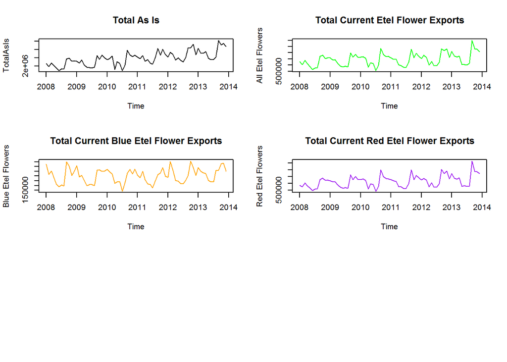

## 4.2 Plots of Plan Data:

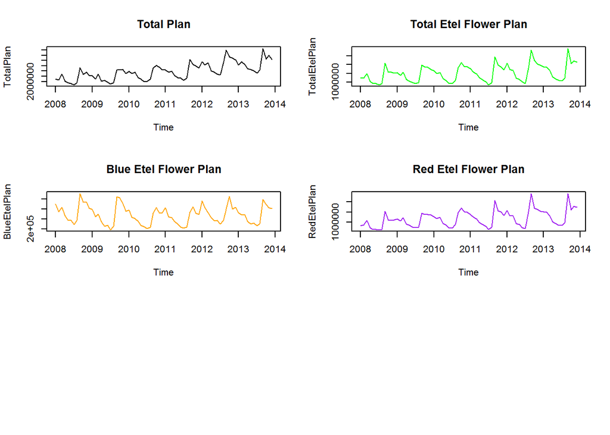

Since the basic plots of the Etel flowers that separate seasonality and trend. Below are some plots that examine the seasonality a little more in depth but add trending. The remainder graph basically identifies any noise in the data that might skew the seasonality or trend data.

The plots below are based on the time series data sets instead of the current data data sets.

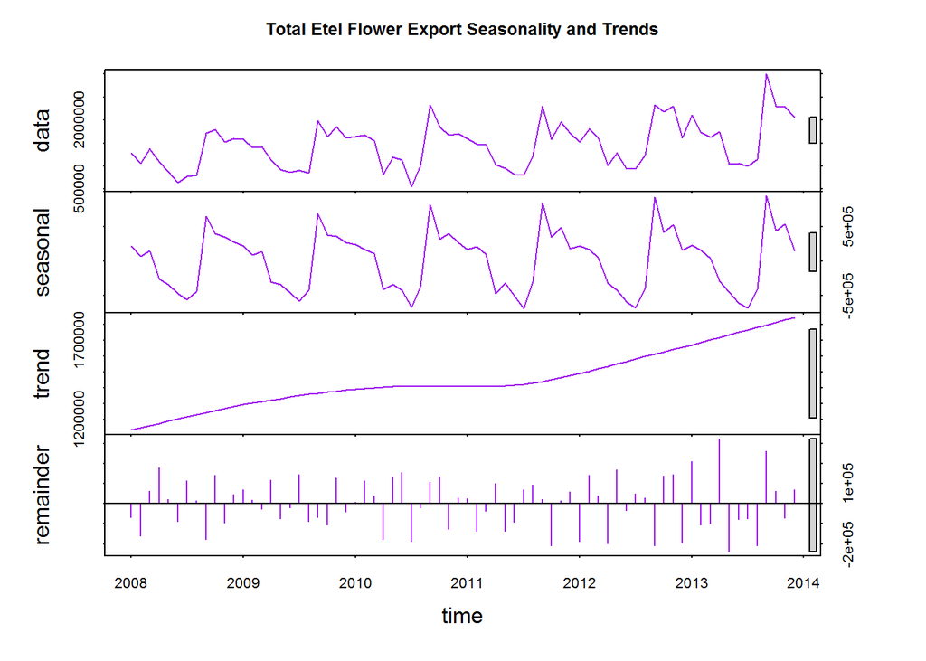

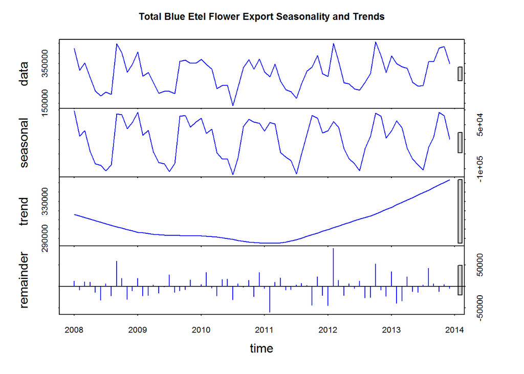

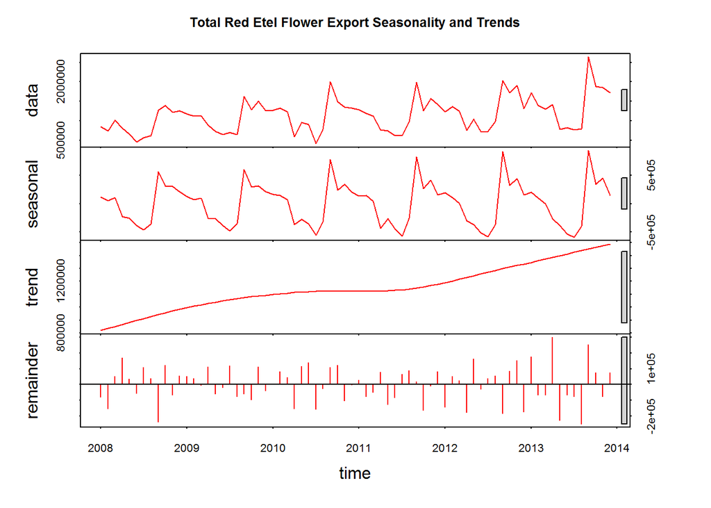

## 4.3 Modify the Seasonal data to view it at a monthly level

Even though the above plots do not indicate that the seasonal and trend plot look identical, breaking the data down by month will an alternative view.

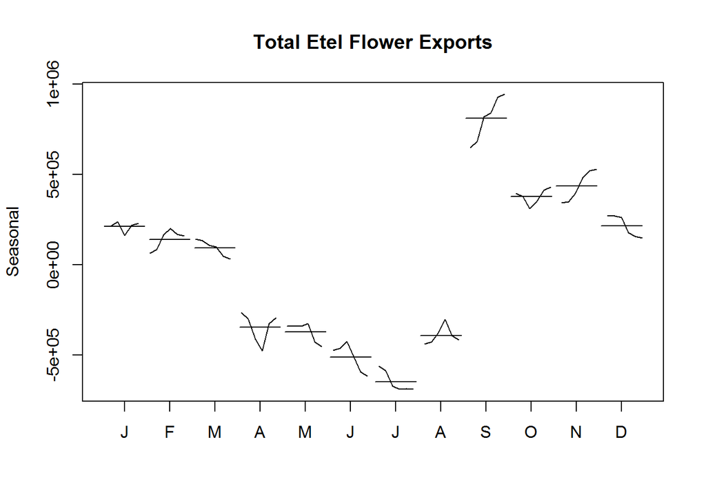

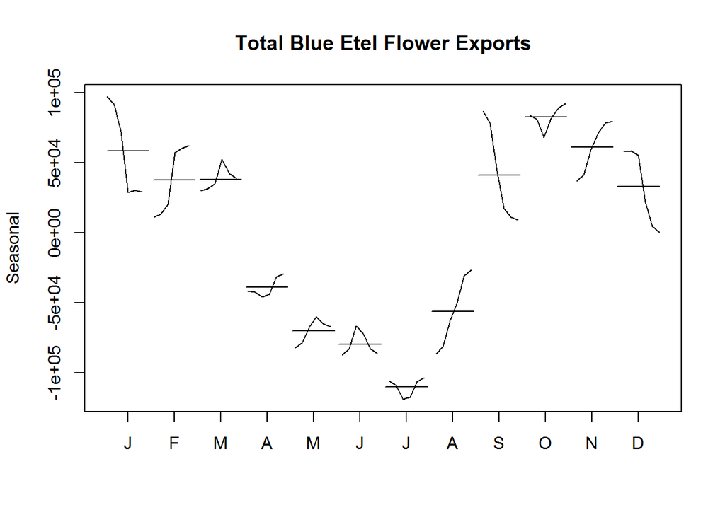

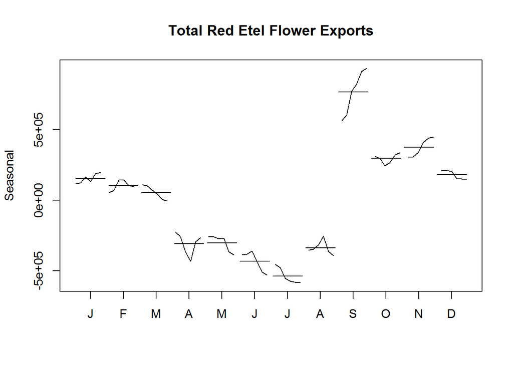

All three plots display a drop in exports in July and a sharp increase in exports in September. The monthly plots do display a trend associated with seasonality that is driven by the temperature in Chulwalar.

## 4.4 Viewing Correlations between the As Is data and the Plan:

Correlation between the Total As Is data and the Total Plan:

```
## [1] 0.9183402
```

Correlation between the Total Etel Flower As Is data and the Total Etel Plan:

```
## [1] 0.9159505
```

Correlation between the Total Blue Etel Flower As Is data and the Total Blue Etel Plan:

```
## [1] 0.8044146
```

Correlation between the Total Red Etel Flower As Is data and the Total Red Etel Plan:

```
## [1] 0.9106702
```

There is a strong correlation between the current As Is data for the Etel flower and the plan data for the Etel Flower. The Blue Etel flower As Is data and Plan correlation is not as strong as the Red Etel flowers.

## 4.5 View the Differences between the As Is data and the Plan data

This analysis is to make sure the plan is accurate and that the data is identical.

View of the Total As Is differences:

```
##
## Call:
## lm(formula = TotalAsIs ~ TotalPlan, data = TotalAsIs)
##
## Residuals:
##     Min      1Q  Median      3Q     Max
## -770214 -196776   26017  182579  672705
##
## Coefficients:
##              Estimate Std. Error t value Pr(>|t|)
## (Intercept) 8.959e+04  1.521e+05   0.589    0.558
## TotalPlan   9.627e-01  4.959e-02  19.413   <2e-16 ***
## ---
## Signif. codes:  0 '***' 0.001 '**' 0.01 '*' 0.05 '.' 0.1 ' ' 1
##
## Residual standard error: 332600 on 70 degrees of freedom
## Multiple R-squared:  0.8433, Adjusted R-squared:  0.8411
## F-statistic: 376.9 on 1 and 70 DF,  p-value: < 2.2e-16
```

View of the Total As Is Time Series data differences

```
##
## Call:
## tslm(formula = TotalAsIs ~ TotalPlan)
##
## Residuals:
##     Min      1Q  Median      3Q     Max
## -770214 -196776   26017  182579  672705
##
## Coefficients:
##              Estimate Std. Error t value Pr(>|t|)
## (Intercept) 8.959e+04  1.521e+05   0.589    0.558
## TotalPlan   9.627e-01  4.959e-02  19.413   <2e-16 ***
## ---
## Signif. codes:  0 '***' 0.001 '**' 0.01 '*' 0.05 '.' 0.1 ' ' 1
##
## Residual standard error: 332600 on 70 degrees of freedom
## Multiple R-squared:  0.8433, Adjusted R-squared:  0.8411
## F-statistic: 376.9 on 1 and 70 DF,  p-value: < 2.2e-16
```

The As Is data and the As Is Time Series data match the plan data. The adjusted R square for both equal 0.8411.

View the Total Etel Flower As Is Data:

```
##
## Call:
## lm(formula = TotalEtelAsIs ~ TotalEtelPlan, data = TotalEtelAsIs)
##
## Residuals:
##     Min      1Q  Median      3Q     Max
## -492888  -99871   -7667   93858  576321
##
## Coefficients:
##                 Estimate Std. Error t value Pr(>|t|)
## (Intercept)   -7.175e+03  8.018e+04  -0.089    0.929
## TotalEtelPlan  9.637e-01  5.046e-02  19.097   <2e-16 ***
## ---
## Signif. codes:  0 '***' 0.001 '**' 0.01 '*' 0.05 '.' 0.1 ' ' 1
##
## Residual standard error: 202900 on 70 degrees of freedom
## Multiple R-squared:  0.839,  Adjusted R-squared:  0.8367
## F-statistic: 364.7 on 1 and 70 DF,  p-value: < 2.2e-16
```

The Etel Flower As Is data and the Etel Flower As Is Time Series data match the plan data for the Etel Flower. The adjusted R square for both equal 0.8367.

View the Total Etel Flower As Is Time Series data Differences:

```
##
## Call:
## tslm(formula = TotalEtelAsIs ~ TotalEtelPlan)
##
## Residuals:
##     Min      1Q  Median      3Q     Max
## -492888  -99871   -7667   93858  576321
##
## Coefficients:
##                 Estimate Std. Error t value Pr(>|t|)
## (Intercept)   -7.175e+03  8.018e+04  -0.089    0.929
## TotalEtelPlan  9.637e-01  5.046e-02  19.097   <2e-16 ***
## ---
## Signif. codes:  0 '***' 0.001 '**' 0.01 '*' 0.05 '.' 0.1 ' ' 1
##
## Residual standard error: 202900 on 70 degrees of freedom
## Multiple R-squared:  0.839,  Adjusted R-squared:  0.8367
## F-statistic: 364.7 on 1 and 70 DF,  p-value: < 2.2e-16
```

### 4.5.1 Correlation of External Indicators

The following Correlation factors were examined to see if there was any impact on the total Etel Flower exports.

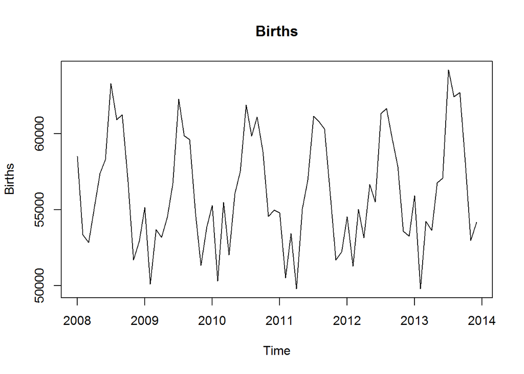

3. Exports from Urbano - there is a slight correlation (0.3182532) but not enough to impact the total Etel Flower exports.
4. Independence Day Presents Indicator - there is a small correlation (0.287213) but not enough to impact the total Etel Flower Exports.
5. Temperature - there is a negative correlation between the average temperature in chulwalar and the exports of the Etel flower. In colder months exports increase and decrease in the warmer months. The correlation of Total Etel flower exports and temperatur is -0.453138.

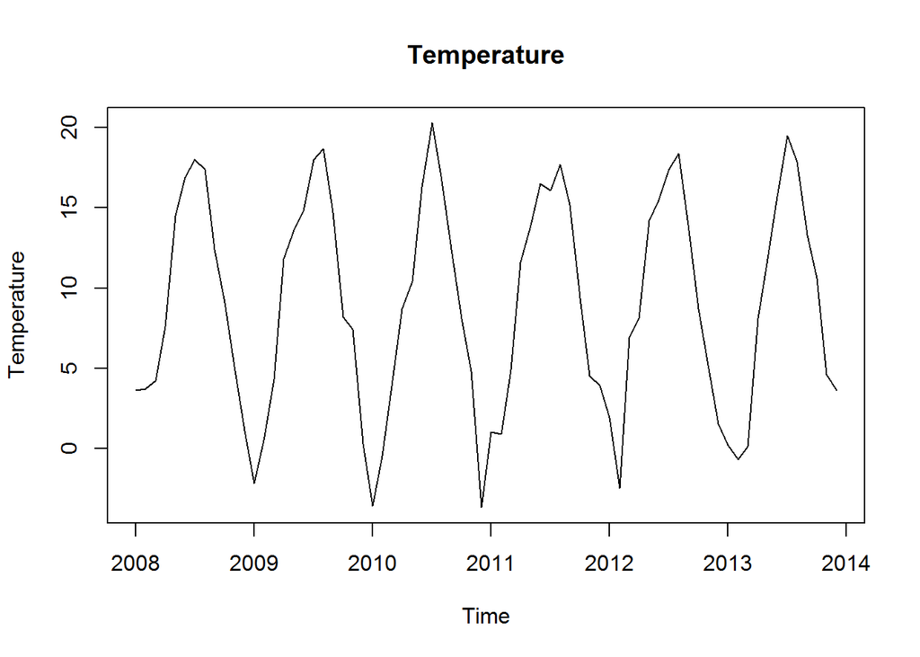

6. Satisfaction Index - there is only a slight correlation between the overall satisfaction index and the export of Etel Flowers. The correlation value was 0.2865672.

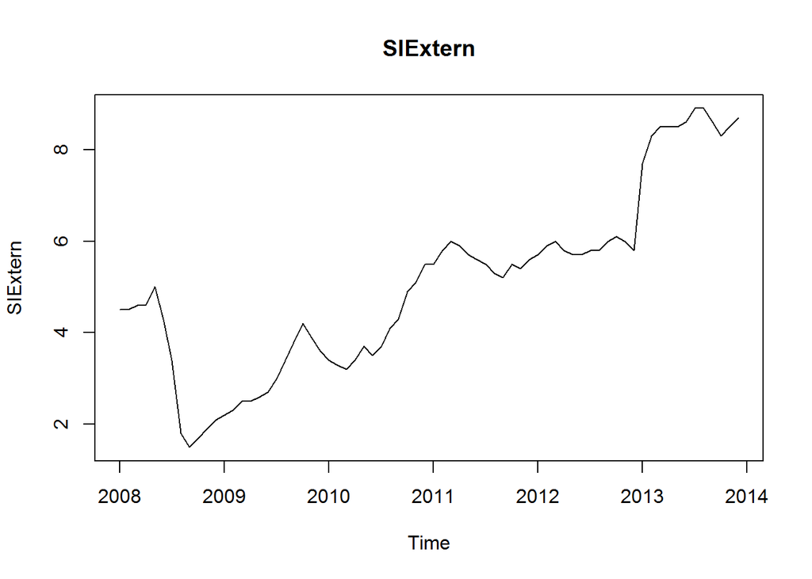

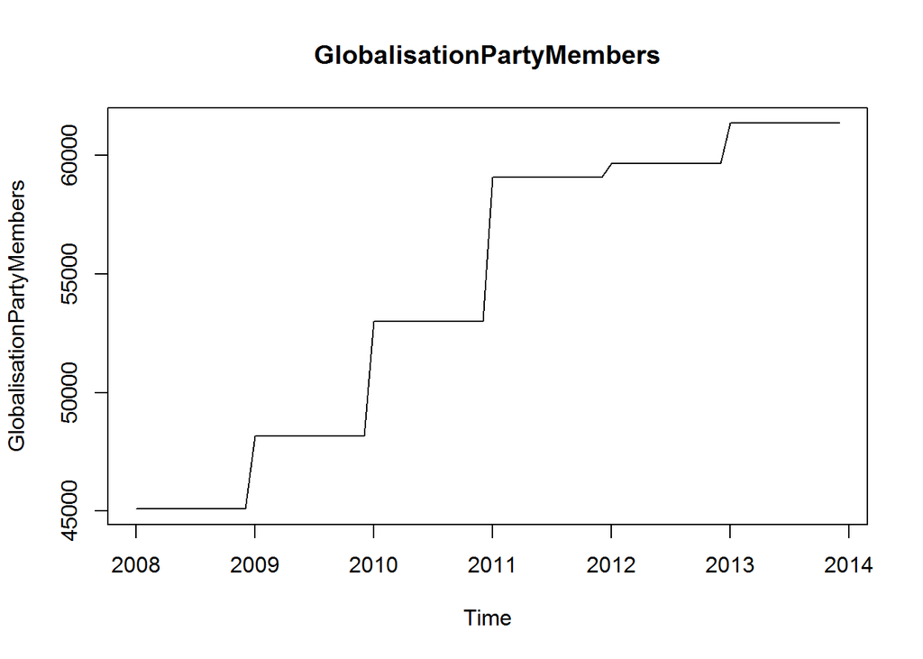

7. Yearly number of Globalisation Party members in Chulwalar - there is not a big enough correlation (0.2994635) to impact the exports of the Etel Flower.
8. Monthly Average Export Price Index in chulwalar - there is not a big enough correlatin (0.3035506) to impact the exports of the Etel Flower. One thought is that continue growth has a postive affect on exports.

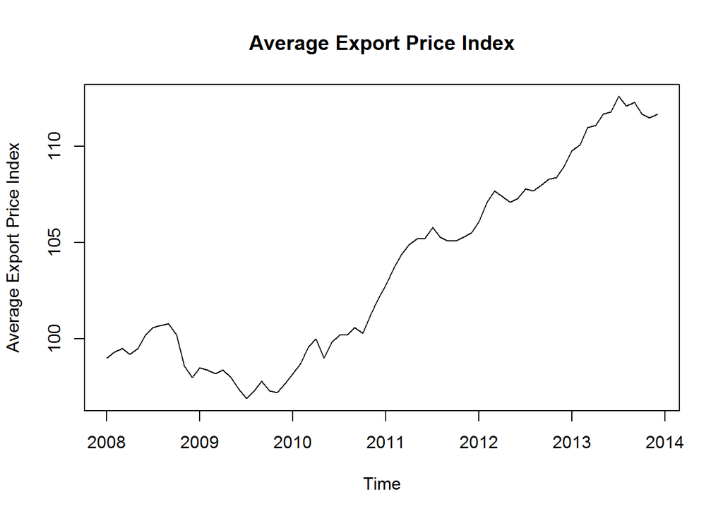

9. Monthly Producer Price Index (PPI) for Etel in Chulwalar - there is not a big enough correlation (0.3374707) to impact the exports of the Etel Flower.

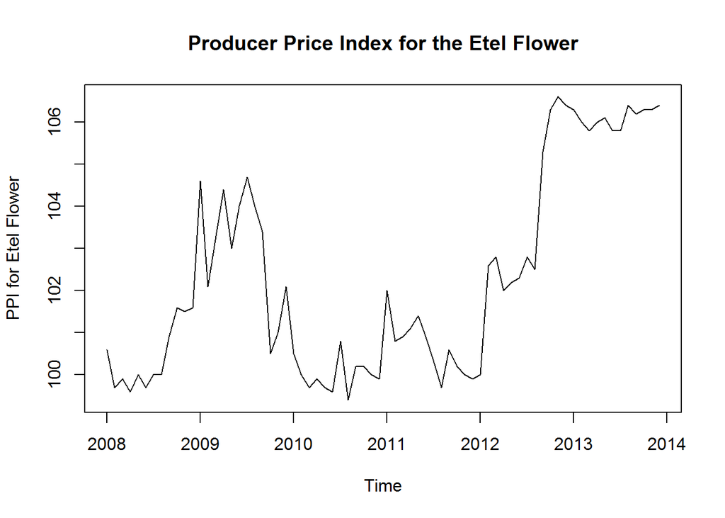

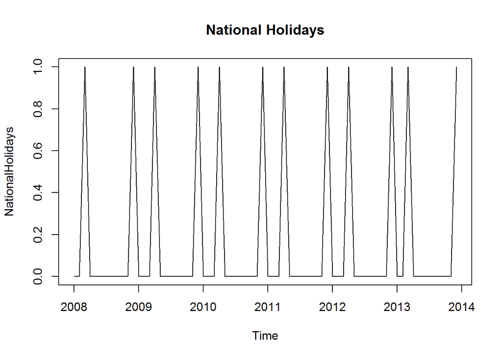

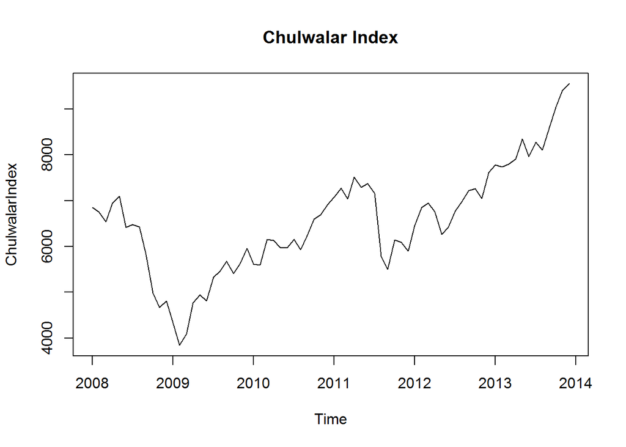

12. Month Inflation rate in Chulwalar - there is a negative correlation (-0.08378282) between inflation and the exports of the Etel flower. The negative correlation is seen with the export of the Red Etel flower (-0.0982151) but not the Blue Etel flower (0.02117817).

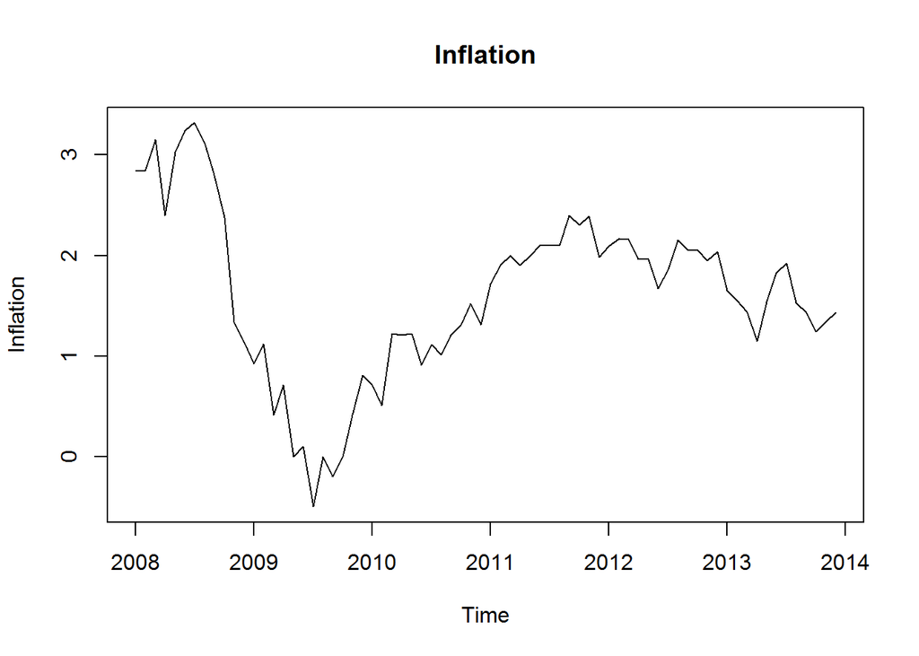

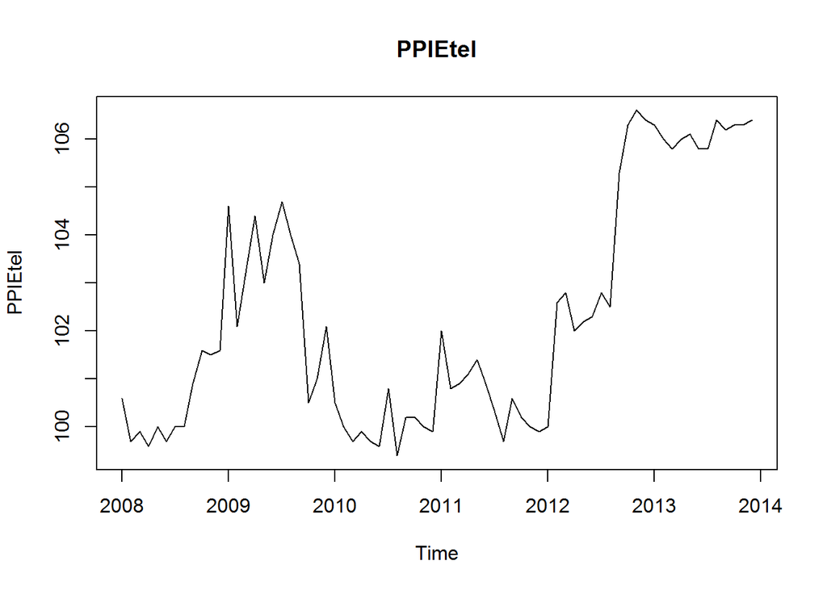

14. Influence National Holidays. This indicator looks at the months leading up to a National holiday to see if exports increase - there is a moderate correlation (0.4535836), but not sure this will help with forecasting future exports

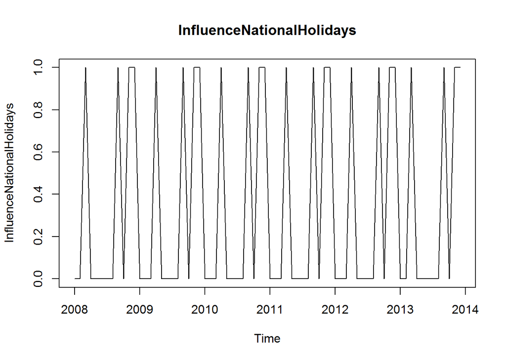

## 4.6 View correlation between exports and external indicators by offsetting the export data by one month.

The purpose of offsetting the export data by one month is to see if the index change makes itself first noticeable on exports in the following months.

External Satisfaction Index indicator is to be offset by one month, to see if the index change makes itself first noticeable on exports in the following months.

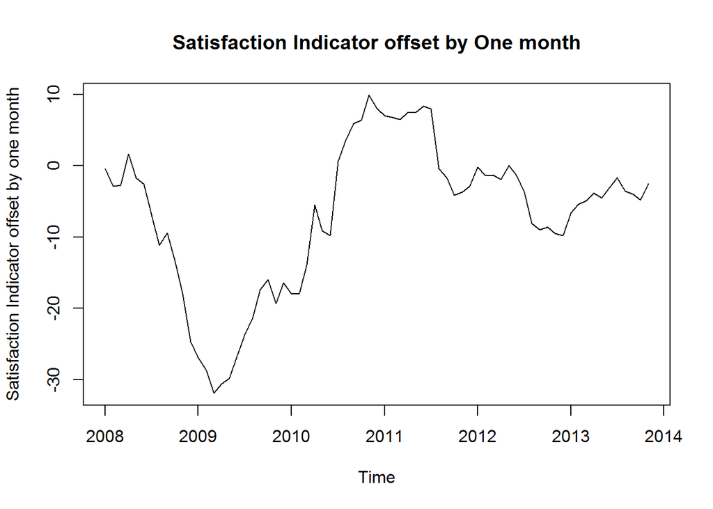

December 2013 was deleted from the data set to see what impact this month has on the Etel Flower exports.

The satisfaction index indicator now has a negative correlation with the Etel Flower Exports - -0.004445279 but this still isn’t enough to have a noticeable impact.

November and December 2013 were removed to see the overall impact on exports of Etel Flowers. The impact is minimal with a correlation of 0.0446355.

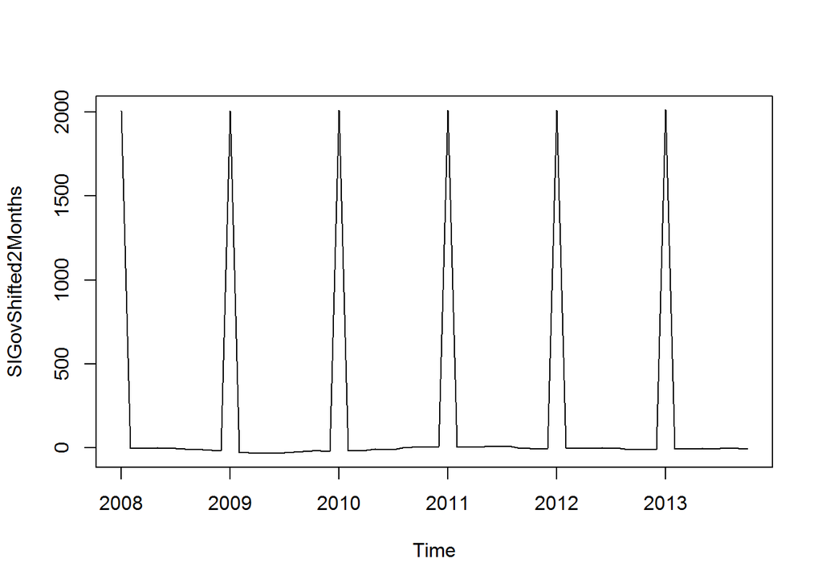

November and December 2013 were removed from the Time Series data set to see if it shows any impact to the overall export of the Etel flowers. Again, there is a minimal impact with a correlation of 0.0446355.

The overall satisifcation and Government Party indicators also did not have any impact on the overall exports of the Etel flowers.

Each of the external indicators were reviewed to see which ones should be included in the final model.

The Correlation Coefficient Matrix shows that CEPI has a high correlation with Overall Satisfication, Urbano Exports, Global Party Members and Average Export Price Index. These will become the set of indicators used later, although there is a risk of multicollinearity.

National Holidays, Urbano Exports, Global Party Members have a very low correlation with one another. Therefore these will also become a set of indicators used later.

## 4.7 Building Forecasting Model: using all external indicators with the Etel Flower Exports

Combining Chulwalar Export Price Index (CEPI), Satisfaction Index - Government, Temperatur, Births, Overall Satisfaction Index, Urbano Exports, Globalisation Party Members, Average Export Price Index, National Holidays, Chulwalar Index, Inflation, and Independence Day presents into one model did not produce any statistically signifcant p-values for any of the external indicators. This indicates that having all the external indicators in one model is not the best model to use for forecasting.

## 4.8 Build Model with the Chulwaler Export Price Index indicator and the Etel Flower Exports

The Adjusted R Squared is at 0.866 which is good but the Chulwaler Export Price Index does not appear to have a statistical impact on the export of the Etel Flowers based on the p-values of the indicator.

## 4.9 Build Model with the Statisfaction Index to view its impact on the Etel Flower Exports

```r
# The Satisfaction Index (gov)  hardly changes the function of the model.
ModelWithSIGov <- tslm(TotalEtelAsIs ~ trend + season + SIGov)
summary(ModelWithSIGov)
```

```
##
## Call:
## tslm(formula = TotalEtelAsIs ~ trend + season + SIGov)
##
## Residuals:
##     Min      1Q  Median      3Q     Max
## -345475 -110285   -8382  113926  461146
##
## Coefficients:
##             Estimate Std. Error t value Pr(>|t|)
## (Intercept)  1303471      84010  15.516  < 2e-16 ***
## trend           9048       1103   8.203 2.80e-11 ***
## season2      -106455     101785  -1.046   0.3000
## season3      -133300     101800  -1.309   0.1956
## season4      -498901     101857  -4.898 8.12e-06 ***
## season5      -604908     101846  -5.939 1.71e-07 ***
## season6      -748213     101898  -7.343 7.78e-10 ***
## season7      -829933     102011  -8.136 3.63e-11 ***
## season8      -634890     102019  -6.223 5.82e-08 ***
## season9       592372     102083   5.803 2.87e-07 ***
## season10      197270     102194   1.930   0.0585 .
## season11      224660     102328   2.195   0.0321 *
## season12       -4578     102540  -0.045   0.9645
## SIGov          -4901       2180  -2.248   0.0284 *
## ---
## Signif. codes:  0 '***' 0.001 '**' 0.01 '*' 0.05 '.' 0.1 ' ' 1
##
## Residual standard error: 176300 on 58 degrees of freedom
## Multiple R-squared:  0.8993, Adjusted R-squared:  0.8767
## F-statistic: 39.85 on 13 and 58 DF,  p-value: < 2.2e-16
```

The Satisification Index - Government does seem to have statistical significant impact on the Etel flower exports. The p-value is 0.0284 for the Satisification Index - Government and the R-squared is 0.8767.

## 4.10 Build Model with the Temperature indicator and its impact on the Etel Flower Exports

The temperature indicator does not do a good job impacting the overall export of the Etel flowers. The Variance inflation factor is 9.40994 and the p-value is 0.196136.

## 4.11 Build Model with National Holidays indicator to review its impact on the Etel flower exports

National Holidays have some impact on the export of Etel Flowers. The Adjusted R Squared is 0.8744 and the p-value 0.0534 for the National Holiday indicator is somewhat statistically significant. The variance inflation factor is high at 9.74823 but this indicator may still be used in the final model.

## 4.12 Build Model with inflation indicator to review its impact on the Etel flower exports

Inflation does not have a statistical impact on the exports of Etel flowers as indicated by the p-value 0.563331 and the variance inflation factor of 9.487. Therefore, the inflation indicator is not a good factor to include in the final model.

## 4.13 Build Model with Independence Day Presents indicator to review its impact on the Etel flower exports

The buying of Independence Day presents does not have a statistical impact on the exports of Etel flowers as indicated by the p-value 0.574184 and the variance inflation factor of 12.15354. Therefore, the buying of Independence Day present indicator is not a good factor to include in the final model.

## 4.14 Build Model with National Holiday indicator to review its impact on the Etel flower exports

The Influence National Holiday indicator has more of an effect on the Red Etel flower export than on the Blue Etel flower. The adjusted Adjusted R Square is 0.8744 and the p-value for the indicator is 0.05336 which is mildly signifcant. The variation inflation factor for the total Etel flower exports is 9.74823.

# 5 Building Models with High Correlating Indicators

High correlating indicators do not show a strong impact on the export of Etel flowers. The adjusted R Square is 0.8706 but the p-values for each of the indicators is not statistically significant.

# 6 Building Models with Low Correlating Indicators

The low correlating indicators chosen were the National Holiday and the Globalization of Party Members. Both seem to have an impact on the exports of the Etel flowers. The adjusted R Square is 0.883 and both p-values for the indicators are statistically significant (National Holiday - 0.0457 and Globalization of Party Members - 0.0256). The variance inflation factor is 10.64726 which is high and an indicator this is not the best model.

# 7 Building Model with Trend and Season only and no other external indicators

```
##
## Call:
## tslm(formula = TotalEtelAsIs ~ trend + season)
##
## Residuals:
##     Min      1Q  Median      3Q     Max
## -352676 -105634    5934  107814  481013
##
## Coefficients:
##             Estimate Std. Error t value Pr(>|t|)
## (Intercept)  1370632      81168  16.886  < 2e-16 ***
## trend           8070       1048   7.702 1.75e-10 ***
## season2      -101964     105202  -0.969   0.3364
## season3      -128812     105218  -1.224   0.2257
## season4      -506178     105244  -4.810 1.08e-05 ***
## season5      -607122     105281  -5.767 3.14e-07 ***
## season6      -751654     105327  -7.136 1.59e-09 ***
## season7      -838360     105385  -7.955 6.51e-11 ***
## season8      -631474     105452  -5.988 1.35e-07 ***
## season9       592436     105531   5.614 5.60e-07 ***
## season10      202397     105619   1.916   0.0602 .
## season11      232807     105718   2.202   0.0316 *
## season12        8713     105827   0.082   0.9347
## ---
## Signif. codes:  0 '***' 0.001 '**' 0.01 '*' 0.05 '.' 0.1 ' ' 1
##
## Residual standard error: 182200 on 59 degrees of freedom
## Multiple R-squared:  0.8905, Adjusted R-squared:  0.8683
## F-statistic:    40 on 12 and 59 DF,  p-value: < 2.2e-16
```

# 8 Building Model without Trend and seasonality.

This model does not work well. The adjusted R square is 0.0728 and none of the p-values for the external indicators are of statisitical significance.

```
##
## Call:
## tslm(formula = TotalEtelAsIs ~ CEPI + SIExtern + UrbanoExports +
##     GlobalisationPartyMembers + AEPI)
##
## Residuals:
##     Min      1Q  Median      3Q     Max
## -826260 -397817   67869  307638 1276508
##
## Coefficients:
##                             Estimate Std. Error t value Pr(>|t|)
## (Intercept)               -9.702e+06  7.756e+06  -1.251    0.215
## CEPI                       1.948e+05  1.206e+05   1.616    0.111
## SIExtern                   1.287e+04  7.271e+04   0.177    0.860
## UrbanoExports              2.056e-01  5.904e-01   0.348    0.729
## GlobalisationPartyMembers -1.410e+01  2.531e+01  -0.557    0.579
## AEPI                      -8.937e+04  7.513e+04  -1.190    0.238
##
## Residual standard error: 483400 on 66 degrees of freedom
## Multiple R-squared:  0.1381, Adjusted R-squared:  0.0728
## F-statistic: 2.115 on 5 and 66 DF,  p-value: 0.07449
```

# 9 Etel Flower Export Model

# 10 Forecasting with Models with Shorten Time series

The time series data sets require that the time be shorten in order to compare the produced forecasts with the current As Is data.

## 10.1 Check High Correlating Indicators

The same results as seen in the previous models is present with this model. The adjusted R Square is 0.8778 but none of the p-values for the external indicators are statistically significant.

### 10.1.1 Adding data to the 2013 indicator values in order to forecast

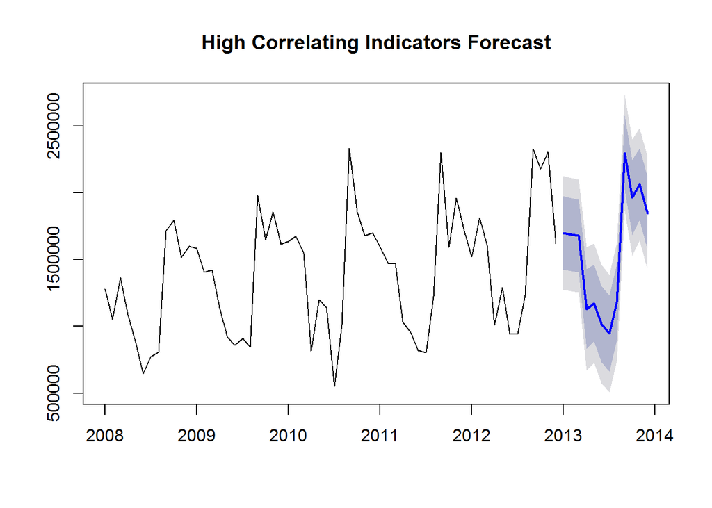

There is a strong correlation between the As is data and the plan data for 2013 for the Etel Flower Exports. The Linear regression comparison supports the results with an adjusted R Square of 0.9144.

## 10.2 Check Low Correlating Indicators

The adjusted R square is 0.8786 but none of the external indicators have a p-value of statistical significance.

### 10.2.1 Adding data to the 2013 Low correlating indicator values in order to forecast

The low correlating indicators forecast model follows the pattern of the existing data for the Etel Flower exports. The linear regression comparsion supports this forecasting model. The adjusted R square is 0.9144 and the F-statistic is 118.5,

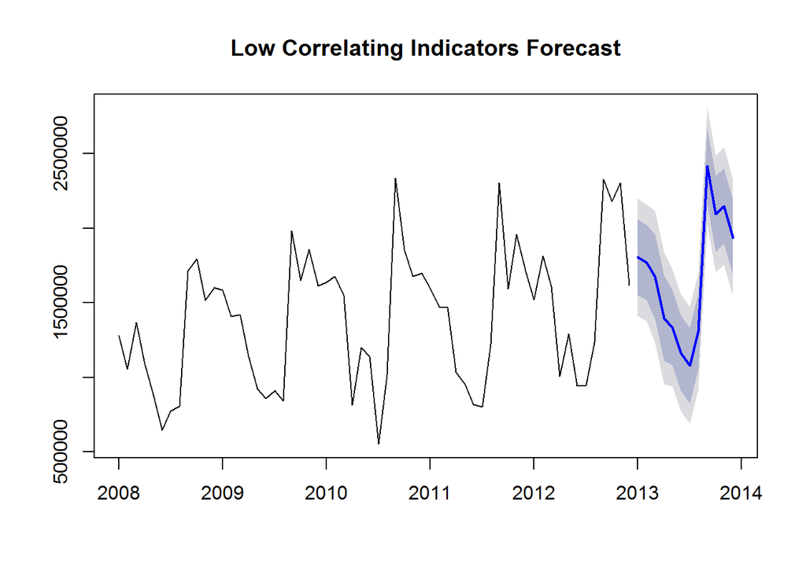

There is a strong correlation with the low correlating indicators and the current as is data for 2013 and the plan data for 2013 for the Etel Flower exports.

## 10.3 Forcasting with only Seasonality and Trend for the Etel Flower Exports

The seasonality and trend work well with this forecasting model. The adjust R Square is 0.8755 and again season 10 and 11 show statistical significance.

### 10.3.1 Adding data to the 2013 Seasonality and Trend for the Forecast model

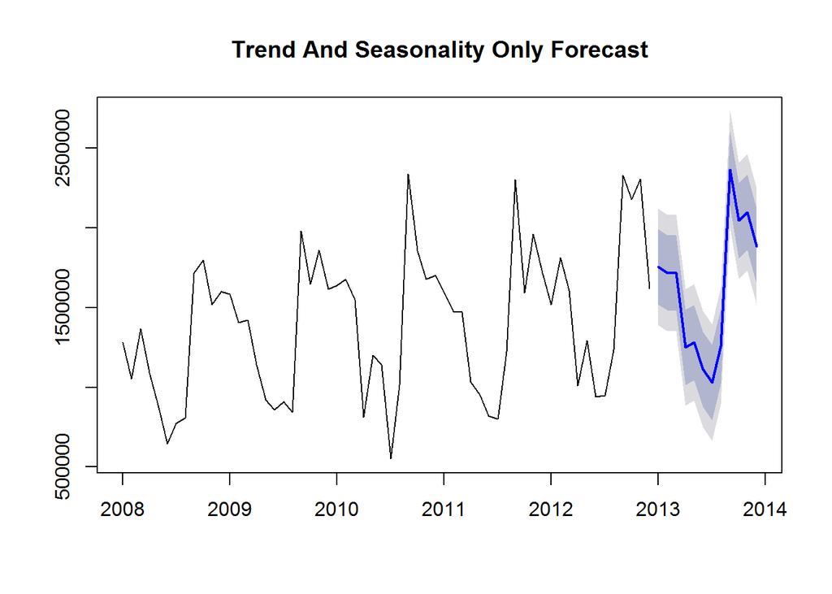

Trend and Seasonality continue to be the best model for the Etel Flower exports. The forecasting model shows a pattern that follows even closer to the current export pattern of the Etel flower. There is a strong correlation between the current export Etel flower data and the plan data for 2013. The linear regression supports this model. The adjusted R Square is 0.9144 and the F-Statistic is 118.5

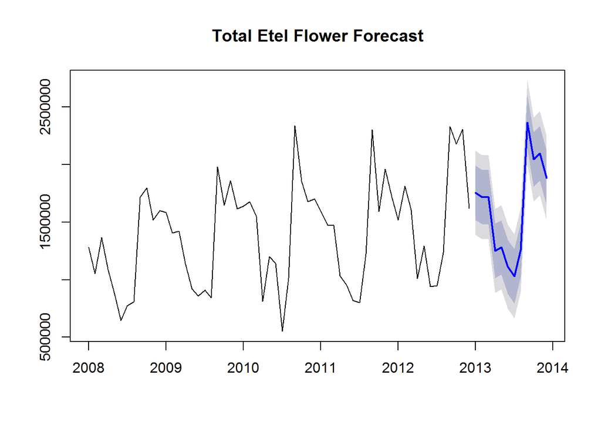

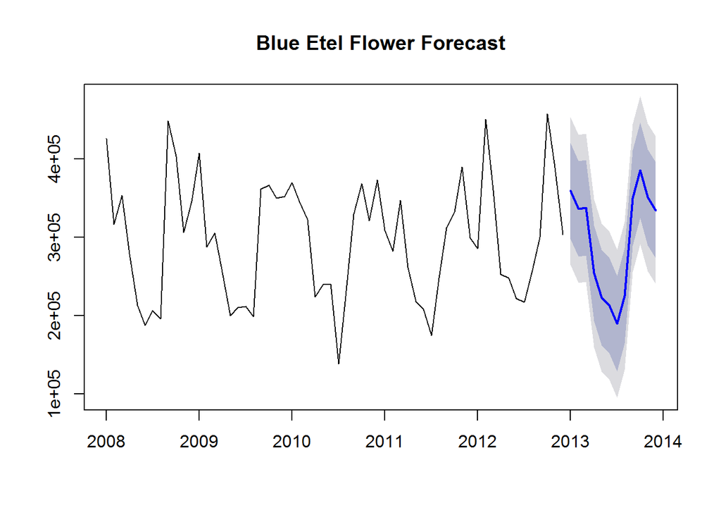

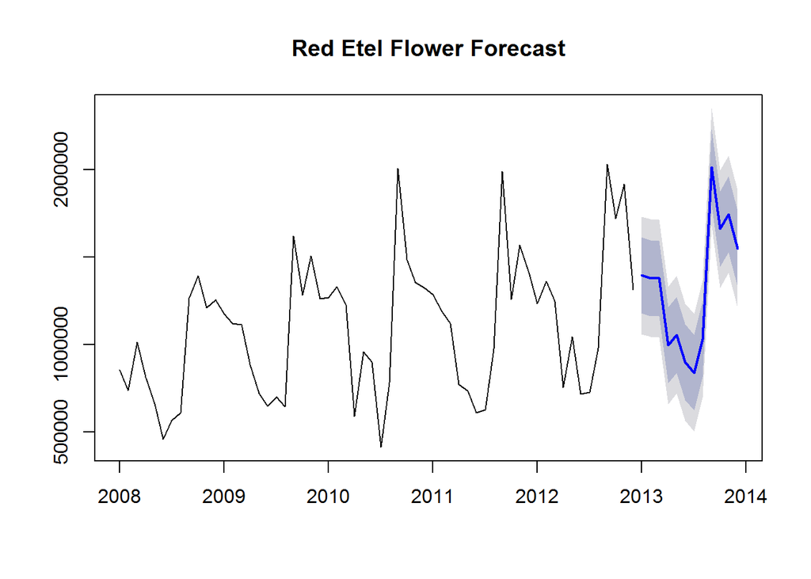

# 11 Forecasting 2014 for the Etel Flower Exports with National Holidays and Globalisation Party Members

```
##
## Call:
## tslm(formula = TotalEtelAsIs ~ trend + season + NationalHolidays +
##     GlobalisationPartyMembers)
##
## Residuals:
##     Min      1Q  Median      3Q     Max
## -339086 -114138   16689  103127  426582
##
## Coefficients:
##                             Estimate Std. Error t value Pr(>|t|)
## (Intercept)               2793808.47  625417.30   4.467 3.81e-05 ***
## trend                       17168.18    4089.10   4.199 9.53e-05 ***
## season2                   -111062.18   99222.63  -1.119  0.26770
## season3                    -75389.44  105469.63  -0.715  0.47765
## season4                   -390235.38  122037.29  -3.198  0.00226 **
## season5                   -643513.72  100478.56  -6.404 3.10e-08 ***
## season6                   -797144.07  101224.64  -7.875 1.11e-10 ***
## season7                   -892947.25  102129.12  -8.743 4.06e-12 ***
## season8                   -695159.60  103187.82  -6.737 8.72e-09 ***
## season9                    519652.89  104396.06   4.978 6.28e-06 ***
## season10                   120515.21  105748.72   1.140  0.25920
## season11                   141827.86  107240.32   1.323  0.19128
## season12                   123490.26  151355.81   0.816  0.41796
## NationalHolidays          -214854.25  105152.08  -2.043  0.04566 *
## GlobalisationPartyMembers     -31.35      13.67  -2.293  0.02557 *
## ---
## Signif. codes:  0 '***' 0.001 '**' 0.01 '*' 0.05 '.' 0.1 ' ' 1
##
## Residual standard error: 171700 on 57 degrees of freedom
## Multiple R-squared:  0.9061, Adjusted R-squared:  0.883
## F-statistic: 39.28 on 14 and 57 DF,  p-value: < 2.2e-16
```

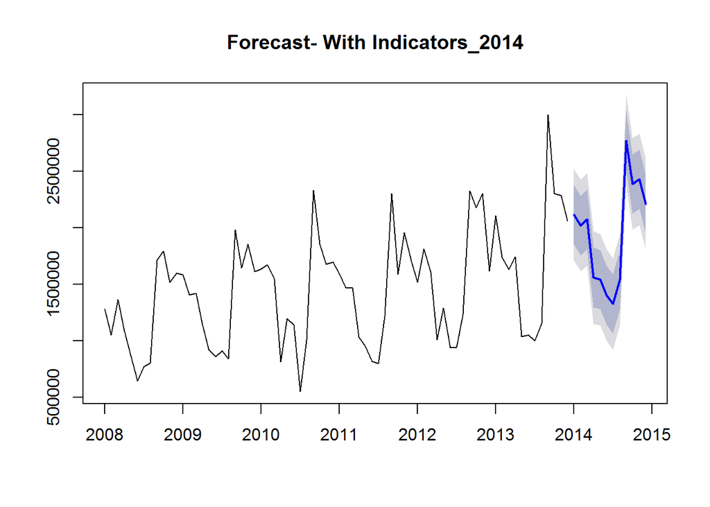

# 12 Forecasting Exports for the Etel Flowers with Seasonality and Trend only for 2014

Seasonality and Trend continue to show a good fit and work well with forecasting for 2014. The adjusted R Square is 0.8683. With this forecast model though Season 10 statistical significance is much lower but Season 11 continues to show statistically signifcance in the Etel flower exports for Chuluwala.

There continues to be a strong correlation between the current export data and the plan data.

```
##
## Call:
## tslm(formula = TotalEtelAsIs ~ trend + season)
##
## Residuals:
##     Min      1Q  Median      3Q     Max
## -352676 -105634    5934  107814  481013
##
## Coefficients:
##             Estimate Std. Error t value Pr(>|t|)
## (Intercept)  1370632      81168  16.886  < 2e-16 ***
## trend           8070       1048   7.702 1.75e-10 ***
## season2      -101964     105202  -0.969   0.3364
## season3      -128812     105218  -1.224   0.2257
## season4      -506178     105244  -4.810 1.08e-05 ***
## season5      -607122     105281  -5.767 3.14e-07 ***
## season6      -751654     105327  -7.136 1.59e-09 ***
## season7      -838360     105385  -7.955 6.51e-11 ***
## season8      -631474     105452  -5.988 1.35e-07 ***
## season9       592436     105531   5.614 5.60e-07 ***
## season10      202397     105619   1.916   0.0602 .
## season11      232807     105718   2.202   0.0316 *
## season12        8713     105827   0.082   0.9347
## ---
## Signif. codes:  0 '***' 0.001 '**' 0.01 '*' 0.05 '.' 0.1 ' ' 1
##
## Residual standard error: 182200 on 59 degrees of freedom
## Multiple R-squared:  0.8905, Adjusted R-squared:  0.8683
## F-statistic:    40 on 12 and 59 DF,  p-value: < 2.2e-16
```

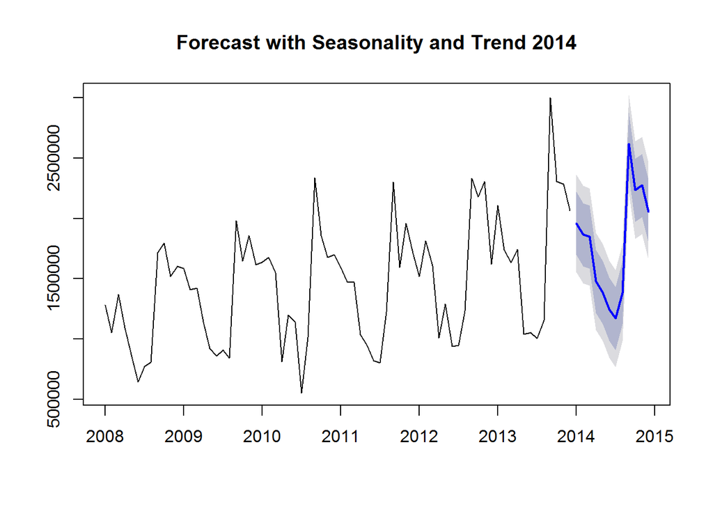

# 13 Using other Modelling Approaches

## 13.1 Exponential Smoothing

The Exponential Smoothing does not seem to be the best model for forecasting 2014. The predicted forecast shows flat exports for th Etel Flower which is not indictive of past years.

```
##
## Forecast method: Simple exponential smoothing
##
## Model Information:
## Simple exponential smoothing
##
## Call:
##  ses(x = TotalEtelAsIs, h = 12)
##
##   Smoothing parameters:
##     alpha = 0.7395
##
##   Initial states:
##     l = 1195425.4826
##
##   sigma:  457693.8
##
##      AIC     AICc      BIC
## 2188.810 2188.984 2193.363
##
## Error measures:
##                    ME     RMSE      MAE       MPE     MAPE     MASE
## Training set 17461.77 457693.8 297227.3 -4.846428 21.14544 1.453283
##                    ACF1
## Training set 0.02266816
##
## Forecasts:
##          Point Forecast     Lo 80   Hi 80      Lo 95   Hi 95
## Jan 2014        2125179 1538620.3 2711737 1228115.06 3022242
## Feb 2014        2125179 1395654.1 2854703 1009467.27 3240890
## Mar 2014        2125179 1276437.7 2973919  827141.42 3423216
## Apr 2014        2125179 1172017.3 3078340  667444.30 3582913
## May 2014        2125179 1077957.7 3172399  523592.49 3726765
## Jun 2014        2125179  991676.6 3258680  391636.90 3858720
## Jul 2014        2125179  911513.9 3338843  269038.63 3981318
## Aug 2014        2125179  836327.5 3414030  154050.92 4096306
## Sep 2014        2125179  765291.7 3485065   45411.04 4204946
## Oct 2014        2125179  697786.7 3552570  -57828.92 4308186
## Nov 2014        2125179  633333.1 3617024 -156402.12 4406759
## Dec 2014        2125179  571551.2 3678806 -250889.44 4501246
```

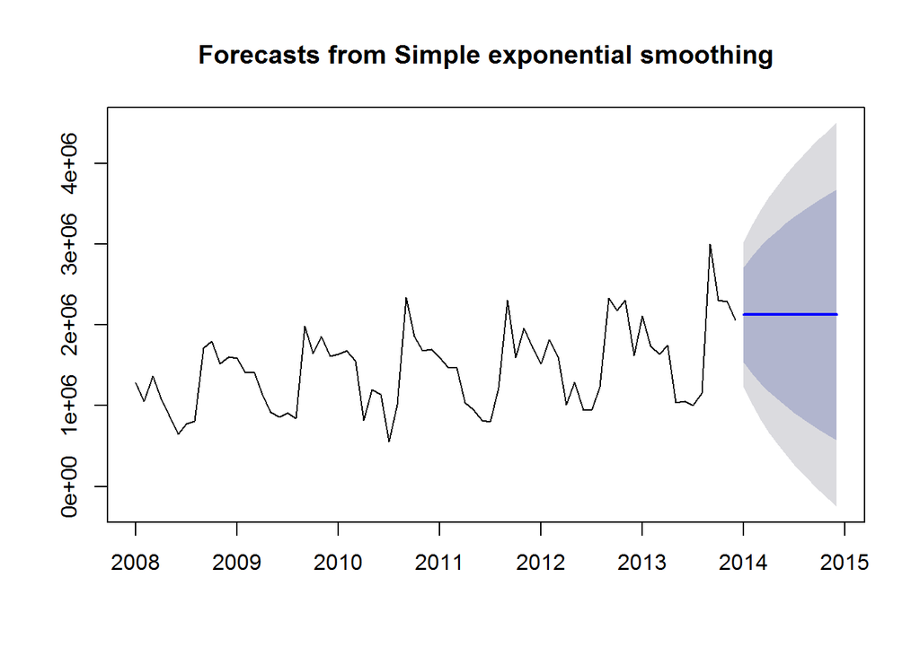

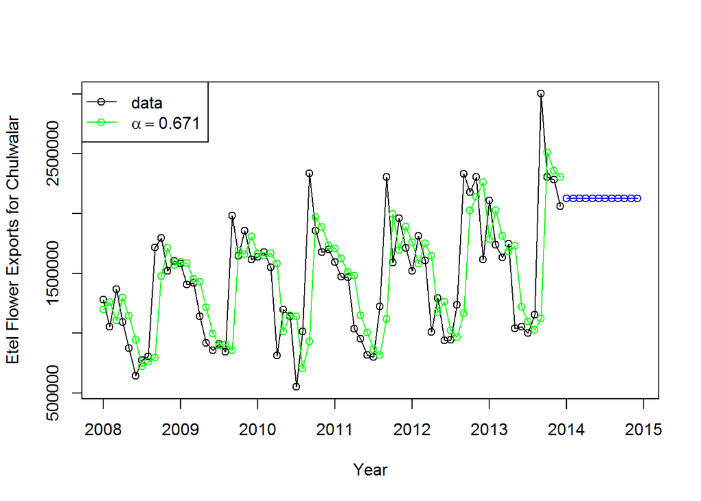